# Alligator Harbor Aquatic Preserve

**Sampling locations by Program:**

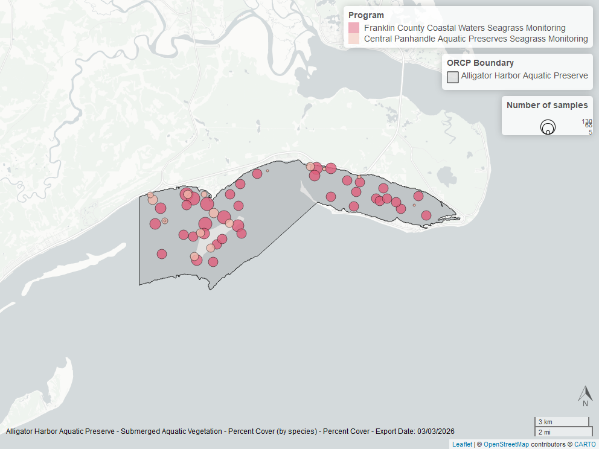

Map showing SAV sampling sites within the boundaries of *Alligator Harbor Aquatic Preserve*. The point size reflects the number of samples at a given sampling site.

Program Information for Submerged Aquatic Vegetation

| ProgramID | N-Data | YearMin | YearMax | method | Sample Locations |
| --- | --- | --- | --- | --- | --- |
| 557 | 531 | 2008 | 2023 | Braun Blanquet | 16 |
| 558 | 2984 | 2009 | 2017 | Percent Cover | 38 |

**Program names:**

*557* - Central Panhandle Aquatic Preserves Seagrass Monitoring<sup>5</sup>  
*558* - Franklin County Coastal Waters Seagrass Monitoring<sup>7</sup>

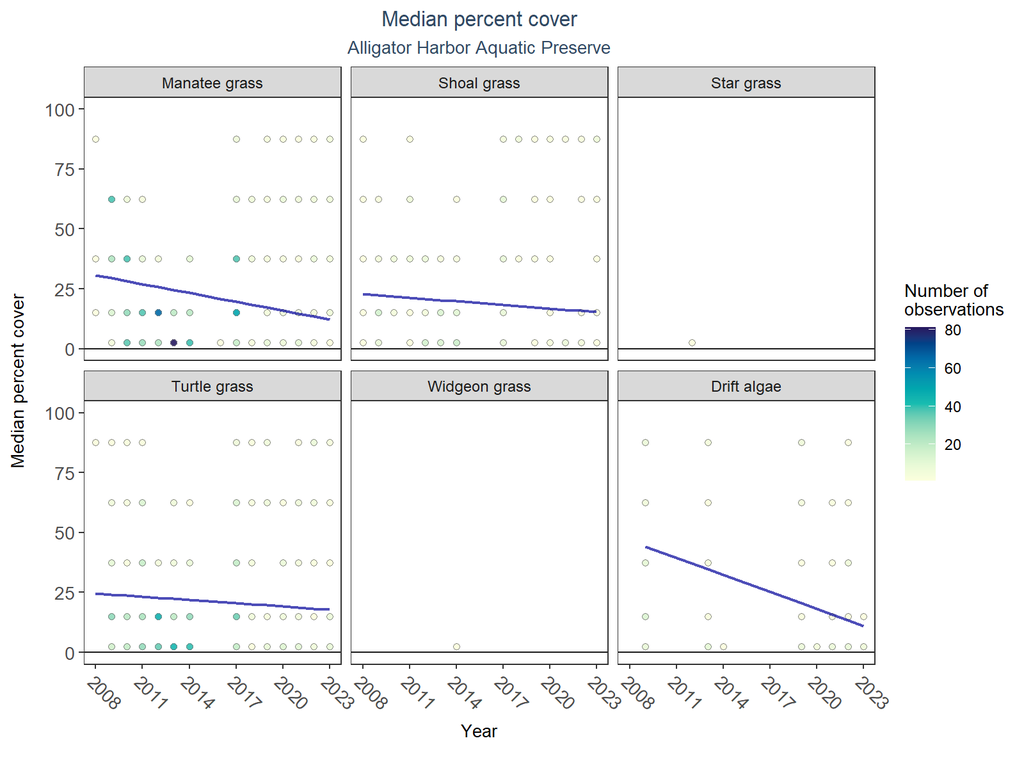

Scatter plots of median percent cover of submerged aquatic vegetation over time by group. Plots for time series that included five or more years of observations show the estimated trend as a blue line.

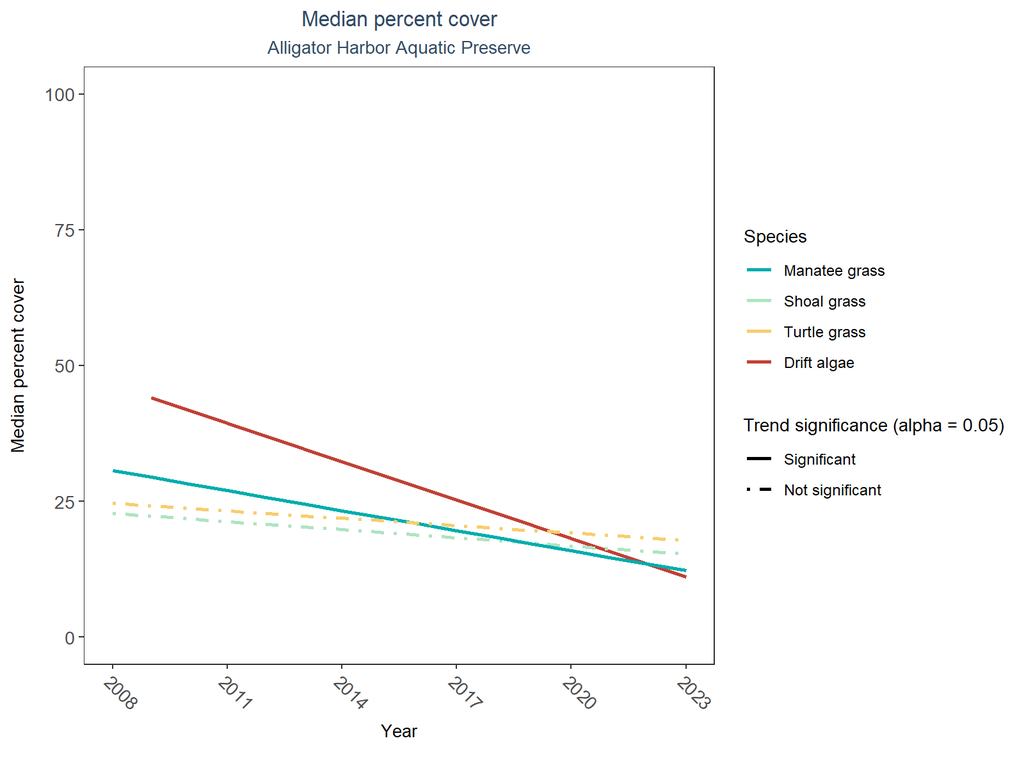

Trend lines of median percent cover of submerged aquatic vegetation over time for species that had five or more years of observations. Line type represents significance (solid) or non-significance (dashed) of the trends.

Percent Cover Trend Analysis for Alligator Harbor Aquatic Preserve

| Species | Statistical Trend | Period of Record | LME Intercept | LME Slope | P |
| --- | --- | --- | --- | --- | --- |
| Drift algae | Decreasing trend | 2009 - 2023 | 79.40245 | -2.3562408 | 0.0273463 |
| Shoal grass | No detectable trend | 2008 - 2023 | 29.78764 | -0.4993668 | 0.4716915 |
| Star grass | Insufficient data | - | - | - | - |
| Widgeon grass | Insufficient data | - | - | - | - |
| Manatee grass | Decreasing trend | 2008 - 2023 | 47.85836 | -1.2281451 | 0.0253568 |
| Turtle grass | No detectable trend | 2008 - 2023 | 30.96903 | -0.4530891 | 0.3778576 |

Annual decreases in percent cover were observed for manatee grass (-1.23%) and drift algae (-2.36%). No detectable change in percent cover was observed for shoal grass and turtle grass. Trends in percent cover could not be evaluated for star grass and widgeon grass due to insufficient data.

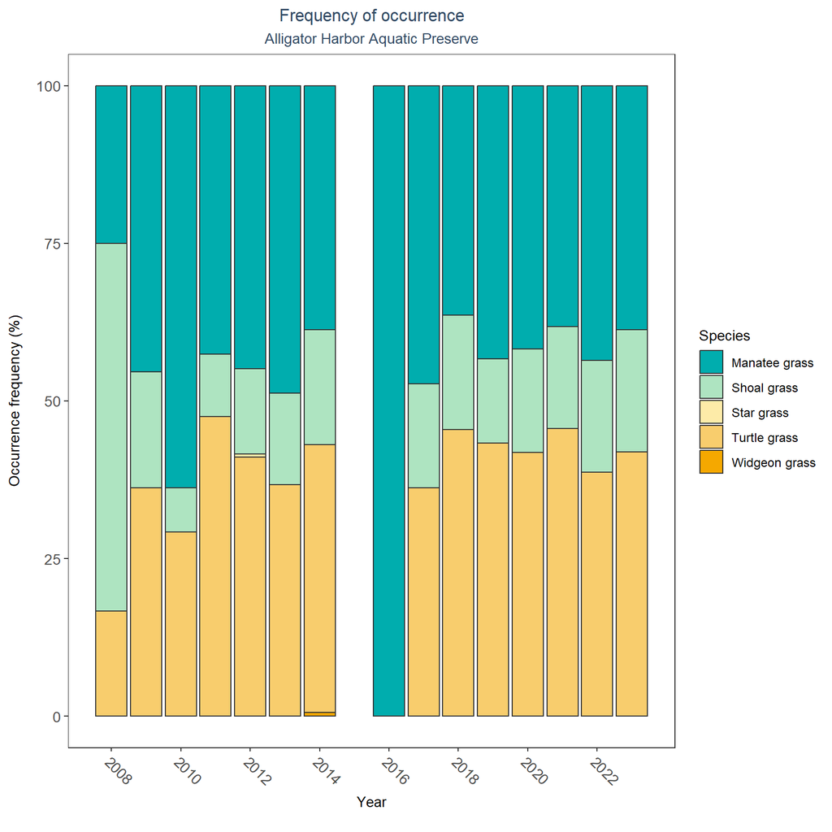

Bar plot of submerged aquatic vegetation species occurrence frequency over time by group.

## SAV Water Column Analysis

The following parameters are available for Alligator Harbor Aquatic Preserve within the SAV_WC_Report:

- Colored Disolved Organic Matter
- Chlorophyll a
- Dissolved Oxygen
- pH
- Salinity
- Secchi Depth
- Water Temperature
- Total Nitrogen
- Turbidity

Access the reports here: DRAFT_SAV_WC_Report.pdf

# Species list

| Acanthophora sp.<sup>1</sup> | Halodule wrightii<sup>1</sup> | Sargassum spp.<sup>1</sup> |
| --- | --- | --- |
| Caulerpa prolifera<sup>1</sup> | Halophila engelmannii<sup>1</sup> | Syringodium filiforme<sup>1</sup> |
| Drift algae<sup>1</sup> | Hypnea<sup>1</sup> | Thalassia testudinum<sup>1</sup> |
| Drift red algae<sup>1</sup> | No grass in quadrat<sup>1</sup> | Yuzurua poiteaui<sup>1</sup> |
| Gracilaria sp.<sup>1</sup> | Ruppia maritima<sup>1</sup> | Acanthophora sp.<sup>1</sup> |

1 - Submerged Aquatic Vegetation

# References

1.

University of Florida (UF); Institute of Food and Agricultural Sciences. [Florida LAKEWATCH Program](https://data.florida-seacar.org/programs/details/514). (2024).

2.

Florida Department of Environmental Protection (DEP). [Florida STORET / WIN](https://data.florida-seacar.org/programs/details/5002). (2024).

3.

Florida Fish and Wildlife Conservation Commission (FWC). [Fisheries-Independent Monitoring (FIM) Program](https://data.florida-seacar.org/programs/details/69). (2022).

4.

Florida Department of Environmental Protection (DEP); Office of Resilience and Coastal Protection (RCP); Central Panhandle Aquatic Preserves. [Central Panhandle Aquatic Preserve WQ Monitoring](https://data.florida-seacar.org/programs/details/469) . (2024).

5.

Florida Department of Environmental Protection (DEP); Office of Resilience and Coastal Protection (RCP); Central Panhandle Aquatic Preserves. [Central Panhandle Aquatic Preserves Seagrass Monitoring](https://data.florida-seacar.org/programs/details/557). (2023).

6.

Florida Fish and Wildlife Conservation Commission (FWC); Florida Fish and Wildlife Research Institute (FWRI). [Harmful Algal Bloom Marine Observation Network](https://data.florida-seacar.org/programs/details/95). (2018).

7.

Florida Department of Environmental Protection (DEP); Office of Resilience and Coastal Protection (RCP); Central Panhandle Aquatic Preserves; Florida Fish and Wildlife Conservation Commission (FWC). [Franklin County Coastal Waters Seagrass Monitoring](https://data.florida-seacar.org/programs/details/558). (2017).

8.

Florida Department of Environmental Protection (DEP); Office of Resilience and Coastal Protection (RCP); Central Panhandle Aquatic Preserves. [Central Panhandle Aquatic Preserves Continuous Water Quality Monitoring](https://data.florida-seacar.org/programs/details/468). (2024).